# The Employment Gap That Unemployment Misses

Women living with young children are less often employed, yet a smaller share are unemployed. The larger difference is among adults outside the labor force.

Labor economics

Childcare

Employment

Women living with young children have a 9.9-point employment shortfall, alongside a slightly smaller unemployed share. Comparing all three labor-market states reveals what unemployment alone leaves out.

Author

Scarlett Xie

Published

September 28, 2026

Modified

October 26, 2026

A nursery pickup can clash with the end of a shift, making the fit between family life and paid work an everyday concern. Employment figures capture a striking contrast. Among women living with a child under six, employment is roughly ten percentage points lower than among women with no minor child at home—yet the share unemployed is slightly smaller. The larger difference is among adults outside the labor force.

**How does employment differ for women and men living with young children, and how much of that difference appears outside the labor force?**

The comparison covers adults aged 25–54, separating those whose youngest own child at home is aged 0–5 from those with no own child under 18 at home.<sup>1, 2</sup> Women and men show opposite employment patterns. Looking at employed, unemployed and nonparticipating adults together makes those patterns easier to interpret than an employment rate alone.

Figure 1. Women’s employment is lowest where children are youngest

Employed per 100 adults, ages 25–54, 2025 survey reference week.

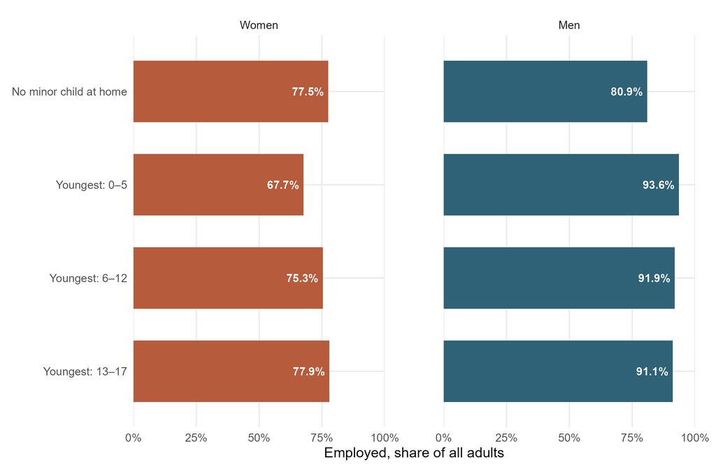

WomenMen

Source: [IPUMS CPS ASEC; author’s weighted estimates](https://cps.ipums.org/cps/). Population and timing.

**Chart notes**

Child age means the youngest own child living at home. The reference group may include parents of adult or nonresident children. These are different groups of people, not families followed as children grow older.

## Lower employment for women, higher employment for men

Among women living with a young child, **67.7%** are employed, compared with **77.5%** among women with no minor child at home. The difference is **9.9 percentage points**: about ten fewer employed women per 100. For men, the comparison runs the other way. Employment is **93.6%** in the young-child group and **80.9%** in the reference group, a **12.7-point advantage**.

The older-child groups sharpen this contrast. Women’s employment rates are much closer to the reference when the youngest child is six or older; men’s rates remain above their reference across all three child groups. The female shortfall is therefore particularly pronounced where children are youngest, rather than appearing equally across all child ages.

A single employment average for women and men would conceal this split in paid work. Even separate employment rates leave an important distinction unresolved: whether adults without jobs are classified as unemployed or are outside the labor force.

## Three in ten women with young children are outside the labor force

The clearest contrast in Figure 2 is outside the labor force: **30.2%** of women in the young-child group, against **19.7%** in the reference group. These adults are neither employed nor classified as unemployed.<sup>3</sup>

Figure 2. Three in ten women with young children are outside the labor force

Each bar divides 100 adults into employed, unemployed and outside the labor force.

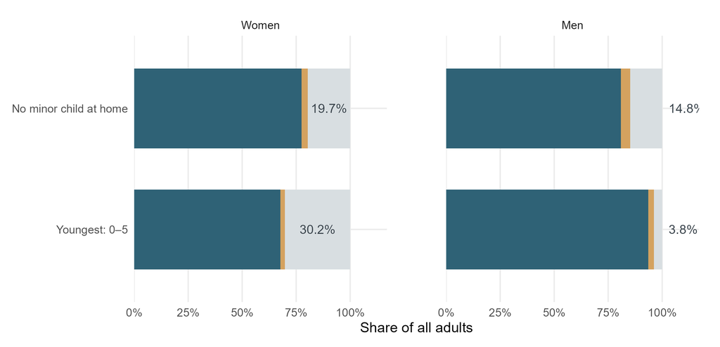

EmployedUnemployedOutside the labor force

Source: [IPUMS CPS ASEC; author’s weighted estimates](https://cps.ipums.org/cps/).

**Chart notes**

Labels identify adults outside the labor force per 100 adults. The unemployed segment also uses all adults as its denominator; it is not the conventional unemployment rate, which uses only labor-force participants. Temporary layoffs are included under the applicable definition.

For men, the pattern again reverses. Just **3.8%** of the young-child group are outside the labor force, compared with **14.8%** in the reference group. High male employment sits alongside a much smaller nonparticipating share, while lower female employment sits alongside a larger one.

The outside-labor-force contrasts are clear, but the narrow unemployed segments are harder to compare by eye. Putting both on the same scale—differences per 100 adults—shows how much each category differs between the child groups.

## Ten more outside the labor force

For every 100 women, the young-child group has **10.6 more outside the labor force** but **0.7 fewer unemployed** than the reference group. Those two differences correspond to **9.9 fewer employed women**. Lower employment here accompanies a slightly smaller unemployed share, rather than a larger one.

Figure 3. The larger contrast is outside the labor force, for women and men alike

Young-child group minus the same-sex group with no minor child at home. Differences in people per 100 adults; positive means more, negative means fewer.

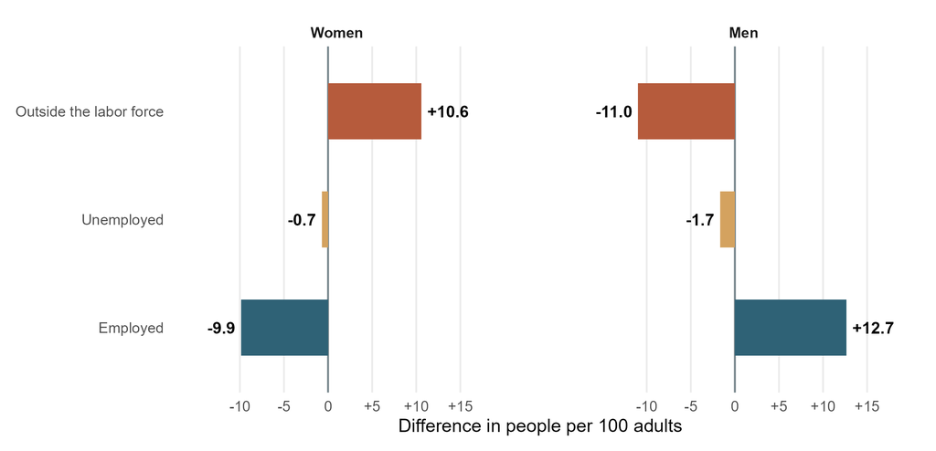

Outside the labor forceUnemployedEmployed: corresponding difference

Source: author’s calculations from the same [IPUMS CPS ASEC](https://cps.ipums.org/cps/) weighted group rates.

**Reading the chart**

The first two rows compare the non-employed categories. The third shows the corresponding employment difference: the three signed differences sum to zero before rounding. The chart compares different groups of adults; it does not show people leaving work or estimate the effects of childcare.

The men’s comparison reinforces the distinction. Per 100 adults, the young-child group has **11.0 fewer outside the labor force** and **1.7 fewer unemployed**, alongside **12.7 more employed**. Despite the opposite employment patterns, the same finding holds for each sex: the outside-labor-force difference is larger than the unemployment difference.<sup>4</sup>

This comparison identifies the composition of the employment gap. It does not establish why participation differs. Childcare, working conditions and household circumstances may matter, but their separate roles are not measured here. Allowing for broad age and education differences changes the employment gaps only slightly; the supporting estimates are available below.<sup>5</sup>

## Takeaway

Women living with young children have employment **9.9 percentage points lower** than their same-sex reference group; men have employment **12.7 points higher**. In both comparisons, differences outside the labor force are larger than differences in unemployment. For women, a smaller unemployed share even offsets a little of the employment shortfall.

These findings support reading employment and unemployment alongside nonparticipation when assessing work and family life. They do not identify which circumstances keep people outside the labor market or which policy would change that. **Read the employment gap alongside nonparticipation, not unemployment alone.**<sup>6</sup>

**A supporting check: does adjusting for age and education change the comparison?**

The regression compares the child groups after allowing for broad age bands and bachelor’s-degree status. Women’s employment gap changes from **9.9** to **10.7 points lower**; men’s from **12.7** to **11.2 points higher**. Adjustment changes neither direction and little of the size, so it adds a modest check rather than a new explanation.

| Comparison | Observed gap (pp) | Adjusted gap (pp) | Adjusted 95% interval (pp) |
| --- | --- | --- | --- |
| Men: young child vs no minor child | +12.7 | +11.2 | [+10.1, +12.4] |
| Women: young child vs no minor child | -9.9 | -10.7 | [-12.3, -9.1] |
| Difference between within-sex gaps (women minus men) | -22.5 | -21.9 | [-23.9, -20.0] |

The women’s adjusted contrast means about **10.7 fewer employed women per 100** within the model’s age and education categories. The men’s contrast has the corresponding interpretation. The last row compares those two gaps; it is not the direct employment difference between women and men. These are adjusted associations, not effects of having children.

## Footnotes

1. Figures are based on the 2025 [IPUMS CPS](https://cps.ipums.org/cps/) survey, weighted to represent adults aged 25–54. Employment refers to the survey reference week.
2. “Young child” means an own child aged 0–5 living at home. The comparison group has no own child under 18 at home; it includes some parents of older or nonresident children. Women and men are compared separately.
3. All chart shares count people per 100 adults in the group. People outside the labor force are neither employed nor classified as unemployed. The usual unemployment rate instead counts unemployed people per 100 labor-force participants.
4. Everyone falls into one of the three states, so more people in one must be balanced by fewer elsewhere. Small discrepancies in the displayed totals reflect rounding.
5. The supporting comparison allows for broad age groups and bachelor’s-degree status. Details and uncertainty estimates accompany the code.
6. The survey compares different people at one point in time. It does not follow families through childbirth or establish why their employment differs. Charts show estimates; confidence intervals are supplied with the results.

## Reproducibility

**Edition status.** The original microdata model was re-estimated in this execution.

The analysis code is included in the accompanying project.

```
index.qmd
README.md
Blog3.Rproj
code/
  01_clean_analyze.R
  02_make_figures.R
  blog3_analysis.R
  install_packages.R
data/
  raw/              # placement instructions; licensed extracts remain private
  processed/        # weighted group rates and adjusted contrasts
result/
  figures/          # three figures generated from estimates
  tables/           # estimates, model diagnostics and execution audit
```

To reproduce the figures, open the website’s RStudio project and keep the post under `blog/posts/post3/`, retaining the folder structure. Keep the IPUMS CPS extract and its XML dictionary together in a private folder. Set `BLOG3_DDI_PATH` to the dictionary path for an existing extract; otherwise configure the private `IPUMS_API_KEY` and CPS registration as described in `README.md`.

Render `blog/posts/post3/index.qmd` to run the complete analysis and rebuild the article, including all three figures and the supporting model table. For standalone use, open `Blog3.Rproj` and render `index.qmd`. Running the scripts separately is optional: use `code/01_clean_analyze.R` followed by `code/02_make_figures.R`, or the combined `code/blog3_analysis.R`.

The scripts generate processed estimates, figures and model tables using project-relative output paths. The default mode refits from the 2025 ASEC microdata. Explicit reference mode uses earlier aggregate files in `data/reference_only/` for review; it does not reproduce a new microdata fit.